# Posterior prediction

A fitted choice model answers questions about choice probabilities: which of two train trips a traveler is likely to book, how the support for a wind-power project changes with the compensation, and how well the model predicts the choices of deciders that were not used for estimation. In the probit model introduced in the vignette [Get started with RprobitB](https://loelschlaeger.de/RprobitB/articles/v01_get_started.html), the choice probability of an alternative is the probability that its latent utility exceeds the utilities of the other alternatives, and it depends on the covariates of the occasion and on the parameters. `predict()` evaluates these probabilities under every retained posterior draw and averages them, so that the predictions account for the posterior uncertainty about the parameters (Gelman et al. 1996). This vignette covers predictions for the population and for individual deciders, scenarios, out-of-sample prediction, residuals, and marginal effects. The examples use data sets of the **mlogit** package (Croissant 2020), the **choicedata** package (Oelschläger 2026), and the **MASS** package (Venables and Ripley 2002).

```r
library(RprobitB)
set.seed(1)
```

## A random price coefficient

The `Train` data of the **mlogit** package contain 5 to 19 choices, about a dozen on average, by each of 235 Dutch travelers between two hypothetical train trips that differ in price, travel time, number of changes, or comfort class (Ben-Akiva et al. 1993). As in the vignette [Get started with RprobitB](https://loelschlaeger.de/RprobitB/articles/v01_get_started.html), the prices are converted to euro and the travel times to hours. That vignette fits one price coefficient for all travelers. Here the price coefficient is a normal random effect, as introduced in the vignette [Modeling preference heterogeneity](https://loelschlaeger.de/RprobitB/articles/v03_heterogeneity.html): every traveler has an individual price coefficient, drawn from a normal population distribution whose mean and variance are estimated. The fit uses the first 100 travelers. The individual draws are saved because the conditional predictions below use them, and thinning keeps 100 draws in total, which keeps the predictions fast.

```r
data("Train", package = "mlogit")
Train$price_A <- Train$price_A / 100 / 2.20371
Train$price_B <- Train$price_B / 100 / 2.20371
Train$time_A <- Train$time_A / 60
Train$time_B <- Train$time_B / 60
train_small <- Train[Train$id %in% unique(Train$id)[1:100], ]
model <- fit(
  choice ~ price + time + change + factor(comfort) | 0,
  data = train_small,
  random_effects = "price",
  column_decider = "id",
  column_occasion = "choiceid",
  iterations = 1500,
  warmup = 750,
  thin = 15,
  chains = 2,
  save_individual_draws = TRUE,
  progress = FALSE
)
summary(model)
```

```
#> Bayesian probit choice model
#> Formula: choice ~ price + time + change + factor(comfort) | 0 | 0
#> Samples: 50 retained per chain, 2 chains
#>
#>                variable   mean   mode     sd  rhat ess_bulk
#>              beta[time] -2.061 -2.096 0.2040 0.996     80.6
#>            beta[change] -0.348 -0.347 0.0581 1.019    124.6
#>  beta[factor(comfort)1] -0.675 -0.702 0.0880 0.997     81.7
#>  beta[factor(comfort)2] -2.155 -2.134 0.1921 0.992     95.8
#>               mu[price] -0.470 -0.492 0.0461 1.011     99.2
#>      Omega[price,price]  0.137  0.121 0.0320 1.017     35.6
```

`mu[price]` and `Omega[price,price]` are the mean and the variance of the price coefficient across the population. Price sensitivity differs considerably between travelers, which the predictions below take into account.

## Population predictions

By default, `predict()` returns one row per choice occasion with the identifiers, the most probable alternative in `.prediction`, and the posterior mean probability of every alternative. These population predictions integrate over the estimated population distribution of the random coefficient, so they apply to any traveler from the population.

```r
population <- predict(model)
head(population)
```

```
#>   id choiceid .prediction probability_A probability_B
#> 1  1        1           A     0.8831176     0.1168824
#> 2  1        2           A     0.7286351     0.2713649
#> 3  1        3           A     0.8307900     0.1692100
#> 4  1        4           B     0.1564283     0.8435717
#> 5  1        5           A     0.7309613     0.2690387
#> 6  1        6           B     0.1555722     0.8444278
```

`uncertainty = TRUE` adds the posterior standard deviation and an equal-tailed credible interval of every probability, here at the 90% level. The intervals reflect the posterior uncertainty about the parameters.

```r
head(predict(model, uncertainty = TRUE, level = 0.9))
```

```
#>   id choiceid .prediction probability_A probability_B       sd_A       sd_B
#> 1  1        1           A     0.8831176     0.1168824 0.02856514 0.02856514
#> 2  1        2           A     0.7286351     0.2713649 0.02988624 0.02988624
#> 3  1        3           A     0.8307900     0.1692100 0.03299359 0.03299359
#> 4  1        4           B     0.1564283     0.8435717 0.02815530 0.02815530
#> 5  1        5           A     0.7309613     0.2690387 0.03237293 0.03237293
#> 6  1        6           B     0.1555722     0.8444278 0.03153192 0.03153192
#>     lower_A    lower_B   upper_A   upper_B
#> 1 0.8288982 0.07442425 0.9255757 0.1711018
#> 2 0.6742942 0.22409280 0.7759072 0.3257058
#> 3 0.7730941 0.11706429 0.8829357 0.2269059
#> 4 0.1189039 0.78948827 0.2105117 0.8810961
#> 5 0.6786981 0.22029219 0.7797078 0.3213019
#> 6 0.1083628 0.78667999 0.2133200 0.8916372
```

## Conditional predictions for fitted deciders

The choices of a traveler are informative about their individual price coefficient. `coef(level = "individual")` returns the posterior mean of every traveler’s coefficient, and `predict(type = "conditional")` uses the individual draws instead of the population distribution. Conditional predictions exist only for the deciders in the fitted data, and they are usually sharper because they use the decider’s own choices. This partial pooling is an important argument for hierarchical choice models (Allenby and Rossi 1998; Huber and Train 2001).

```r
head(coef(model, level = "individual"))
```

```
#>         price
#> 1 -0.26656892
#> 2 -0.88587512
#> 3 -0.72677872
#> 4 -0.45796939
#> 5 -0.02111384
#> 6 -0.06105135
```

```r
conditional <- predict(model, type = "conditional")
head(conditional)
```

```
#>   id choiceid .prediction probability_A probability_B
#> 1  1        1           A     0.9514486     0.0485514
#> 2  1        2           A     0.6045667     0.3954333
#> 3  1        3           A     0.8572995     0.1427005
#> 4  1        4           B     0.1814329     0.8185671
#> 5  1        5           A     0.6087101     0.3912899
#> 6  1        6           B     0.1130333     0.8869667
```

The hit rate, the share of correctly predicted choices in the fitted data, is one measure of the gain:

```r
observed <- model.frame(model)$choice
c(
  population = mean(population$.prediction == observed, na.rm = TRUE),
  conditional = mean(conditional$.prediction == observed, na.rm = TRUE)
)
```

```
#>  population conditional
#>    0.733871    0.816129
```

The hit rate evaluates the predictions at a single threshold, a probability of one half. An ROC curve compares them at every threshold: as the threshold for predicting trip `B` decreases from one to zero, the curve plots the share of `B` choices predicted correctly against the share of `A` choices wrongly predicted as `B`. The **plotROC** package (Sachs 2017) draws the curves with **ggplot2** (Wickham 2016).

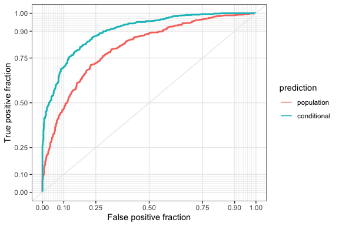

```r
library(ggplot2)
library(plotROC)
roc_data <- rbind(
  data.frame(
    prediction = "population", chose_B = as.integer(observed == "B"),
    probability = population$probability_B
  ),
  data.frame(
    prediction = "conditional", chose_B = as.integer(observed == "B"),
    probability = conditional$probability_B
  )
)
roc_data$prediction <- factor(
  roc_data$prediction, levels = c("population", "conditional")
)
roc_plot <- ggplot(
  roc_data, aes(d = chose_B, m = probability, color = prediction)
) +
  geom_roc(n.cuts = 0) +
  style_roc()
roc_plot
```

The conditional curve lies above the population curve and therefore has the larger area under the curve, which equals one for a perfect and one half for an uninformative prediction.

## Scenario analysis in a stated choice experiment

A scenario predicts the choice probabilities for modified attributes. In Norway, 308 residents were asked six times to choose between two plans for a proposed wind-power project near Setskog and the status quo without the project, alternative `1` (Dugstad et al. 2024). The plans varied the number and height of the turbines, the placement of the power line, and an annual reduction in municipal taxes offered as compensation. The study also measured each respondent’s collective psychological ownership of the affected area, a standardized score of how strongly they feel that the landscape belongs to the residents. The score does not vary across alternatives and therefore enters the second part of the formula, which gives it one coefficient per plan relative to the status quo. The fit uses the first 150 respondents.

```r
wind_formula <- choice ~ turbines + height + powerline + compensation |
  psychological_ownership
```

```r
data("wind_power_choice", package = "choicedata")
respondents <- unique(wind_power_choice$respondent)[1:150]
wind_small <- wind_power_choice[
  wind_power_choice$respondent %in% respondents,
]
wind <- fit(
  formula = wind_formula,
  data = wind_small,
  column_decider = "respondent",
  column_occasion = "occasion",
  iterations = 10000,
  warmup = 5000,
  thin = 10,
  chains = 1,
  progress = FALSE
)
coef(wind)[c("beta[compensation]", "beta[psychological_ownership_2]")]
```

```
#>              beta[compensation] beta[psychological_ownership_2]
#>                      0.00133451                     -0.48509346
```

The compensation coefficient is positive and the ownership coefficient negative: compensation makes a plan more attractive, and residents with a stronger feeling of ownership are less willing to leave the status quo.

What would happen if the municipality doubled the compensation? `newdata` accepts a data frame in the layout of the fitted data, with or without the response column. The scenario below doubles the compensation of both plans in the first four choice tasks and compares the probability of the status quo before and after.

```r
tasks <- model.frame(wind)[1:4, ]
tasks$choice <- NULL
scenario <- tasks
scenario$compensation_2 <- 2 * scenario$compensation_2
scenario$compensation_3 <- 2 * scenario$compensation_3
cbind(
  before = predict(wind, newdata = tasks)$probability_1,
  after = predict(wind, newdata = scenario)$probability_1
)
```

```
#>         before     after
#> [1,] 0.3186877 0.1770411
#> [2,] 0.2810356 0.1677610
#> [3,] 0.2917504 0.2161854
#> [4,] 0.3495430 0.2729819
```

Doubling the compensation lowers the probability of the status quo in all four tasks.

## Out-of-sample prediction and calibration

Predictive performance is best judged on deciders that were not used for estimation (Vehtari et al. 2017). In an arena tournament on the chess server Lichess, a player may go Berserk at the start of a game: the clock is halved, and a win earns one extra tournament point. Players on a winning streak collect double points, so a loss is more costly for them. The `lichess_berserk_choice` data of the **choicedata** package record this decision for 5852 players in the Lichess Yearly Rapid Arena of April 2026, game by game, together with the playing color, the player’s rating, the rating difference to the opponent, the remaining tournament time, and whether the player was on a streak. All covariates describe the game and are constant across the two alternatives, so they enter the second part of the formula, which gives each of them one coefficient for the alternative `TRUE` relative to `FALSE`, for example `beta[rating_TRUE]`. Logical covariates appear as dummy variables such as `streakTRUE`.

```r
berserk_formula <- berserk ~ 0 | white + rating + ratingDifference +
  minutesRemaining + streak
```

The fit uses the games of the first 300 players. `train_test()` splits them by decider: `test_number = 60` puts all games of 60 players into the test set and the games of the other players into the training set.

```r
data("lichess_berserk_choice", package = "choicedata")
players <- unique(lichess_berserk_choice$deciderID)
first_players <- lichess_berserk_choice$deciderID %in% players[1:300]
split <- train_test(lichess_berserk_choice[first_players, ], test_number = 60)
berserk <- fit(
  formula = berserk_formula,
  data = split$train,
  column_occasion = "occasionID",
  iterations = 1000,
  warmup = 500,
  chains = 2,
  progress = FALSE
)
coef(berserk)
```

```
#>        beta[whiteTRUE_TRUE]           beta[rating_TRUE]
#>                3.022943e-02                1.502152e-03
#> beta[ratingDifference_TRUE] beta[minutesRemaining_TRUE]
#>                6.298809e-05               -1.708920e-04
#>       beta[streakTRUE_TRUE]              beta[ASC_TRUE]
#>               -7.920489e-02               -3.261744e+00
```

The rating coefficient is positive: stronger players go Berserk more often. The coefficients of the streak and of the remaining time are negative. How well does the model predict the games of the 60 players in the test set? `newdata` takes the test set as it is, and the predicted alternative is compared with the observed one.

```r
holdout_prediction <- predict(berserk, newdata = split$test)
holdout_choice <- as.character(split$test$berserk)
c(
  accuracy = mean(holdout_prediction$.prediction == holdout_choice),
  share_berserk = mean(split$test$berserk)
)
```

```
#>      accuracy share_berserk
#>     0.6810700     0.3497942
```

The hit rate is only slightly higher than the share of games without Berserk, which the rule that never predicts Berserk would already reach, so the hit rate alone is a weak criterion for an unbalanced binary response. A calibration analysis assesses the predicted probabilities instead. It groups the hold-out games by predicted Berserk probability in intervals of width 0.1 and compares the mean predicted probability with the observed Berserk rate in each group; groups with fewer than 50 games are dropped.

```r
predicted <- holdout_prediction$probability_TRUE
bins <- cut(predicted, breaks = seq(0, 1, by = 0.1))
calibration <- data.frame(
  games = as.vector(table(bins)),
  predicted = as.vector(tapply(predicted, bins, mean)),
  observed = as.vector(tapply(split$test$berserk, bins, mean)),
  row.names = levels(bins)
)
large <- calibration[calibration$games >= 50, ]
round(large, 2)
```

```
#>           games predicted observed
#> (0.1,0.2]    56      0.14     0.18
#> (0.2,0.3]   202      0.25     0.25
#> (0.3,0.4]    74      0.36     0.35
#> (0.4,0.5]    81      0.43     0.57
```

The calibration plot shows the same table. Points on the diagonal mean that the predicted probability equals the observed rate, and the point sizes grow with the number of games in a group.

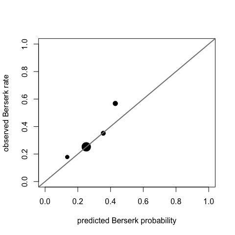

```r
plot(
  large$predicted, large$observed,
  xlim = c(0, 1), ylim = c(0, 1), pch = 19,
  cex = 0.5 + 2 * large$games / max(large$games),
  xlab = "predicted Berserk probability",
  ylab = "observed Berserk rate"
)
abline(0, 1, lwd = 2, col = "grey50")
```

The observed Berserk rate rises with the predicted probability, so the model orders the games by their Berserk rate. In the group with the highest predictions, the observed rate exceeds the predicted probability, so the model underpredicts Berserk for these games.

## Residuals

`residuals()` returns the observed choice indicators minus the posterior mean probabilities, one row per choice occasion and one column per alternative. The rows of observed occasions sum to zero, and occasions with a missing response yield `NA`. A single residual is uninformative, because the indicator is zero or one while the probability lies in between, so the residuals are averaged over groups of occasions. The average residual per traveler shows whose choices the model reproduces:

```r
model_residuals <- residuals(model)
head(model_residuals)
```

```
#>              A          B
#> 1:1  0.1168824 -0.1168824
#> 1:2  0.2713649 -0.2713649
#> 1:3  0.1692100 -0.1692100
#> 1:4 -0.1564283  0.1564283
#> 1:5 -0.7309613  0.7309613
#> 1:6 -0.1555722  0.1555722
```

```r
by_decider <- tapply(
  model_residuals[, "A"], model.frame(model)$id, mean, na.rm = TRUE
)
round(quantile(by_decider, c(0, 0.25, 0.5, 0.75, 1)), 3)
```

```
#>     0%    25%    50%    75%   100%
#> -0.340 -0.066 -0.006  0.067  0.344
```

Most travelers have an average residual close to zero. For the travelers at the extremes, the model predicts trip `A` too often or too rarely across all their questions. Grouping by a covariate checks the functional form instead, here by the price of trip `A` in four groups of about equal size:

```r
price_group <- cut(
  model.frame(model)$price_A,
  breaks = quantile(model.frame(model)$price_A, seq(0, 1, 0.25)),
  include.lowest = TRUE
)
round(tapply(model_residuals[, "A"], price_group, mean, na.rm = TRUE), 3)
```

```
#> [0.454,11.2]  (11.2,14.5]  (14.5,18.2]  (18.2,56.7]
#>        0.024        0.000        0.008       -0.010
```

All four group averages are close to zero. A systematic pattern, for example positive residuals at both ends, could indicate a nonlinear price effect or an unmodeled preference class.

## Marginal effects

How much does one euro more change the probability of booking a trip? The coefficients do not answer this directly, because the probit link is nonlinear: the same change of a covariate moves the probability most where the alternatives are close in utility and little where one alternative dominates. `interpret()` therefore differentiates the predicted probabilities numerically. `type = "mea"` evaluates the derivative for one occasion whose covariates equal the observed averages, reported in the column `at`. `type = "ame"` evaluates the derivative for every observed occasion and averages, which weights the occasions as they occur in the data. Both use every posterior draw and therefore come with credible intervals.

```r
interpret(model, type = "mea")
```

```
#> Marginal effects at the average covariate values
#> Change in the probability of the alternative per unit of the covariate, with 95% interval
#>  covariate alternative     at   mean     sd  lower   upper
#>       time           A  2.115 -0.822 0.0813 -0.961 -0.6776
#>       time           B  2.105 -0.822 0.0813 -0.961 -0.6776
#>     change           A  0.652 -0.139 0.0231 -0.191 -0.0915
#>     change           B  0.679 -0.139 0.0231 -0.191 -0.0915
#>      price           A 15.452 -0.187 0.0184 -0.218 -0.1592
#>      price           B 15.523 -0.187 0.0184 -0.218 -0.1592
```

```r
average_effects <- interpret(model, type = "ame")
average_effects
```

```
#> Average marginal effects on the choice probabilities
#> Change in the probability of the alternative per unit of the covariate, with 95% interval
#>  covariate alternative    mean      sd   lower   upper
#>       time           A -0.4555 0.03649 -0.5229 -0.3922
#>       time           B -0.4555 0.03649 -0.5229 -0.3922
#>     change           A -0.0770 0.01234 -0.1038 -0.0515
#>     change           B -0.0770 0.01234 -0.1038 -0.0515
#>      price           A -0.0865 0.00604 -0.0969 -0.0752
#>      price           B -0.0865 0.00604 -0.0969 -0.0752
```

Averaged over the observed occasions, one euro more lowers the probability of a trip by about 9 percentage points, and it falls at a rate of about 46 percentage points per hour of travel time.

The `at` argument replaces the averages of selected covariates. A much cheaper trip `B` moves its probability close to the share of travelers with a negative price coefficient, where one euro more changes it only marginally:

```r
interpret(model, type = "mea", at = c(price_A = 30, price_B = 10))
```

```
#> Marginal effects at the given covariate values
#> Change in the probability of the alternative per unit of the covariate, with 95% interval
#>  covariate alternative     at      mean       sd     lower     upper
#>       time           A  2.115 -0.048781 7.35e-03 -0.064862 -0.035414
#>       time           B  2.105 -0.048781 7.35e-03 -0.064862 -0.035414
#>     change           A  0.652 -0.008225 1.60e-03 -0.011192 -0.005565
#>     change           B  0.679 -0.008225 1.60e-03 -0.011192 -0.005565
#>      price           A 30.000 -0.000191 3.96e-05 -0.000281 -0.000131
#>      price           B 10.000 -0.000191 3.96e-05 -0.000281 -0.000131
```

## Predictions for ordered responses

An ordered model compares one latent utility per occasion with increasing thresholds that partition it into the levels of the response, as the vignette [Model specification and variants](https://loelschlaeger.de/RprobitB/articles/v02_model_variants.html) describes. For such a model, `predict()` returns the probability of every level. The smoking model of that vignette predicts how often a student smokes from their age and exercise habits.

```r
data("survey", package = "MASS")
smoking <- fit(
  Smoke ~ Age + Exer,
  data = survey,
  alternatives = c("Never", "Occas", "Regul", "Heavy"),
  choice_type = "ordered",
  column_decider = NULL,
  chains = 1
)
head(predict(smoking))
```

```
#>   deciderID .prediction probability_Never probability_Occas probability_Regul
#> 1         1       Never         0.8490272        0.06556796        0.05518716
#> 2         2       Never         0.7965986        0.08039991        0.07426108
#> 3         3       Never         0.7974454        0.08012806        0.07393536
#> 4         4       Never         0.7928818        0.08152295        0.07567253
#> 5         5       Never         0.8422456        0.06778697        0.05777115
#> 6         6       Never         0.8457698        0.06667315        0.05643385
#>   probability_Heavy
#> 1        0.03021762
#> 2        0.04874043
#> 3        0.04849114
#> 4        0.04992269
#> 5        0.03219627
#> 6        0.03112321
```

Every row has four probabilities that sum to one, and `.prediction` names the most probable level. Because most students never smoke, this level is the most probable for every student, and the probabilities are more informative than the predicted level. A scenario works as before. Ten more years of age shift the probability of never smoking of the first three students:

```r
students <- model.frame(smoking)[1:3, ]
students$Smoke <- NULL
older <- students
older$Age <- older$Age + 10
cbind(
  before = predict(smoking, newdata = students)$probability_Never,
  after = predict(smoking, newdata = older)$probability_Never
)
```

```
#>         before     after
#> [1,] 0.8490272 0.8353562
#> [2,] 0.7965986 0.7814142
#> [3,] 0.7974454 0.7825660
```

The probabilities change only slightly, because the age coefficient is small.

## Further reading

Predictions describe what a model expects, not whether it is better than another model. That comparison is the subject of the vignette [Bayesian model evaluation](https://loelschlaeger.de/RprobitB/articles/v05_model_evaluation.html).

## References

Allenby, Greg M., and Peter E. Rossi. 1998. “Marketing Models of Consumer Heterogeneity.” *Journal of Econometrics* 89 (1-2): 57–78. https://doi.org/10.1016/S0304-4076(98)00055-4.

Ben-Akiva, Moshe, Denis Bolduc, and Mark Bradley. 1993. “Estimation of Travel Choice Models with Randomly Distributed Values of Time.” *Transportation Research Record* 1413: 88–97. https://trid.trb.org/View/385096.

Croissant, Yves. 2020. “Estimation of Random Utility Models in R: The mlogit Package.” *Journal of Statistical Software* 95 (11): 1–41. https://doi.org/10.18637/jss.v095.i11.

Dugstad, Anders, Roy Brouwer, Kristine Grimsrud, Gorm Kipperberg, Henrik Lindhjem, and Ståle Navrud. 2024. “Nature Is Ours! Psychological Ownership and Preferences for Wind Energy.” *Energy Economics* 129: 107239. https://doi.org/10.1016/j.eneco.2023.107239.

Gelman, Andrew, Xiao-Li Meng, and Hal Stern. 1996. “Posterior Predictive Assessment of Model Fitness via Realized Discrepancies.” *Statistica Sinica* 6 (4): 733–807. https://www3.stat.sinica.edu.tw/statistica/j6n4/j6n41/j6n41.htm.

Huber, Joel, and Kenneth Train. 2001. “On the Similarity of Classical and Bayesian Estimates of Individual Mean Partworths.” *Marketing Letters* 12 (3): 259–69. https://doi.org/10.1023/A:1011120928698.

Oelschläger, Lennart. 2026. *choicedata: Working with Choice Data*. https://doi.org/10.32614/CRAN.package.choicedata.

Sachs, Michael C. 2017. “plotROC: A Tool for Plotting ROC Curves.” *Journal of Statistical Software, Code Snippets* 79 (2): 1–19. https://doi.org/10.18637/jss.v079.c02.

Vehtari, Aki, Andrew Gelman, and Jonah Gabry. 2017. “Practical Bayesian Model Evaluation Using Leave-One-Out Cross-Validation and WAIC.” *Statistics and Computing* 27 (5): 1413–32. https://doi.org/10.1007/s11222-016-9696-4.

Venables, William N., and Brian D. Ripley. 2002. *Modern Applied Statistics with s*. 4th ed. Springer.

Wickham, Hadley. 2016. *Ggplot2: Elegant Graphics for Data Analysis*. Springer. https://doi.org/10.1007/978-3-319-24277-4.